# 14.Example 3

Modified

Fr 2024-09-06 06:43

## Given:

A diffuse, fire brick wall of temperature $T_s = 500\ \mathrm{K}$ has the spectral emissivity shown below and is exposed to a bed of coals at $2000\ \mathrm{K}$.

Figure 1: Spectral Emissivity

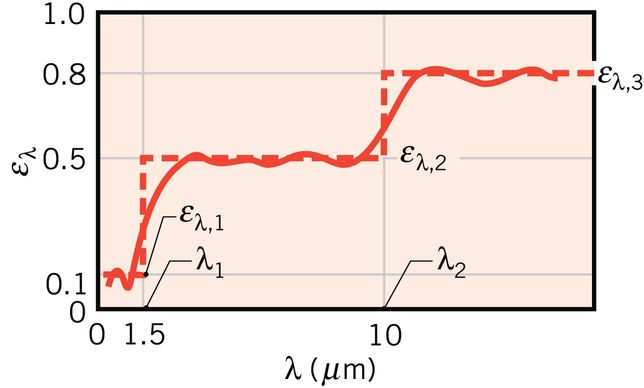

## Required:

Determine the total, hemispherical emissivity and emissive power of the fire brick wall. What is the total absorptivity of the wall to irradiation resulting from emission by the coals?

## Solution:

Start first by defining all of the given values.

$$T_s = 500\ \mathrm{K}$$
$$T_c = 2000\ \mathrm{K}$$
$$\varepsilon_1 = 0.1$$
$$\varepsilon_2 = 0.5$$
$$\varepsilon_3 = 0.8$$
$$\lambda_1 = 1.5\ \mathrm{µm}$$
$$\lambda_2 = 10\ \mathrm{µm}$$

Other known quantities that will be used are shown below.

$$\sigma = 5.67\times 10^{-8}\ \frac{\mathrm{W}}{\left(\mathrm{K}^{4} \cdot \mathrm{m}^{2}\right)}$$

The total, hemispherical emissivity of the wall is given by

$$\varepsilon \left( T_s \right) = \frac{\int_0^{\infty} \varepsilon_\lambda \left( \lambda \right) E_{\lambda, b} \left(\lambda, T_s \right) d \lambda}{E_b \left( T_s \right)}$$

The integral in the numerator may be split into different intervals.

$$\varepsilon \left( T_s \right) = \frac{\int_0^{\lambda_1} \varepsilon_1 E_{\lambda, b} \left(\lambda, T_s \right) d \lambda}{E_b \left( T_s \right)} + \frac{\int_{\lambda_1}^{\lambda_2} \varepsilon_2 E_{\lambda, b} \left(\lambda, T_s \right) d \lambda}{E_b \left( T_s \right)} + \frac{\int_{\lambda_2}^\infty \varepsilon_3 E_{\lambda, b} \left(\lambda, T_s \right) d \lambda}{E_b \left( T_s \right)}$$

For the different intervals, the emissivities are constant so they may taken out of the integrals. The remaining fractions may be seen as the $F$ of Table 9 in Quiz 5 Formula Sheet. The above expression may be simplified to

$$\varepsilon \left( T_s \right) = \varepsilon_1 F_{0 \rightarrow \lambda_1} + \varepsilon_2 F_{\lambda_1 \rightarrow \lambda_2} + \varepsilon_3 F_{\lambda_2 \rightarrow \infty} = \varepsilon_1 F_{0 \rightarrow \lambda_1} + \varepsilon_2 \left( F_{0 \rightarrow \lambda_2} - F_{0 \rightarrow \lambda_1} \right) + \varepsilon_3 \left( F_{0 \rightarrow \infty} - F_{0 \rightarrow \lambda_2} \right)$$

To use Table 9, the product of the wavelength and temperature is used.

$$(\lambda T)_1 = \lambda_1 T_s = 750.0\ \mathrm{K} \cdot \mathrm{µm}$$

$$(\lambda T)_2 = \lambda_2 T_s = 5000\ \mathrm{K} \cdot \mathrm{µm}$$

For $(\lambda T)_2$, no interpolation is needed.

$$F_{0 \rightarrow \lambda_2} = 0.633747$$

Recalling the definition of the $F$ term in Table 9, it may be realized that $F_{0 \rightarrow \infty}$ is one. The total, hemispherical emissivity is then

Answer, part 1: $\varepsilon_s = \varepsilon_1 F_{0 \rightarrow \lambda_1} + \varepsilon_2 (F_{0 \rightarrow \lambda_2} - F_{0 \rightarrow \lambda_1}) + \varepsilon_3 (1 - F_{0 \rightarrow \lambda_2}) = 0.609871$

The total emissive power is then

Answer, part 2: $E_s = \varepsilon_s \sigma T_s^4 = 2.161\ \frac{\mathrm{kW}}{\mathrm{m}^{2}}$

The total absorptivity of the wall to radiation from the coals is

$$\alpha = \frac{\int_0^\infty \alpha_\lambda \left( \lambda \right) G_\lambda \left( \lambda \right) d \lambda}{\int_0^\infty G_\lambda \left( \lambda \right) d \lambda}$$

Since the surface is diffuse, the absorptivity is equal to the emissivity (i.e., $\alpha_\lambda ( \lambda ) = \varepsilon_\lambda ( \lambda )$). Moreover, since the spectral distribution of the irradiation approximates that due to emission from a blackbody at $2000\ \mathrm{K}$, the irradiation is proportional to the emissive power (i.e., $G \lambda ( \lambda) \propto E_{\lambda, b} ( \lambda, T_c)$). The total absorptivity becomes

$$\alpha = \frac{\int_0^\infty \varepsilon_\lambda ( \lambda ) E_{\lambda, b} ( \lambda, T_c ) d \lambda}{\int_0^\infty E_{\lambda, b} ( \lambda, T_c ) d \lambda}$$

The integral may be split into different intervals and becomes

$$\alpha = \varepsilon_1 F_{0 \rightarrow \lambda_1} + \varepsilon_2 \left( F_{0 \rightarrow \lambda_2} - F_{0 \rightarrow \lambda_1} \right) + \varepsilon_3 \left( 1 - F_{0 \rightarrow \lambda_2} \right)$$

To find the $ F $ terms, the product of the wavelength and temperature are needed. This is shown below.

$$(\lambda T)_1 = \lambda_1 T_c = 3000.0\ \mathrm{K} \cdot \mathrm{µm}$$

$$(\lambda T)_2 = \lambda_2 T_c = 20000\ \mathrm{K} \cdot \mathrm{µm}$$

Table 9 may now be used to find the $F$ terms. No interpolation is needed.

$$F_{0 \rightarrow \lambda_1} = 0.273232$$
$$F_{0 \rightarrow \lambda_2} = 0.985602$$

The total absorptivity is then

Answer, part 3: $\alpha = \varepsilon_1 F_{0 \rightarrow \lambda_1} + \varepsilon_2 (F_{0 \rightarrow \lambda_2} - F_{0 \rightarrow \lambda_1}) + \varepsilon_3 (1 - F_{0 \rightarrow \lambda_2}) = 0.395027$